# Early Blindness Shapes Cortical Representations of Auditory Frequency within Primary Auditory Cortex

6/4/2019

## Background

- Human primary auditory cortex (PAC) is tonotopically organized
- Tonotopic organization refers to the systematic spatial arrangement of frequencies representation within auditory cortices

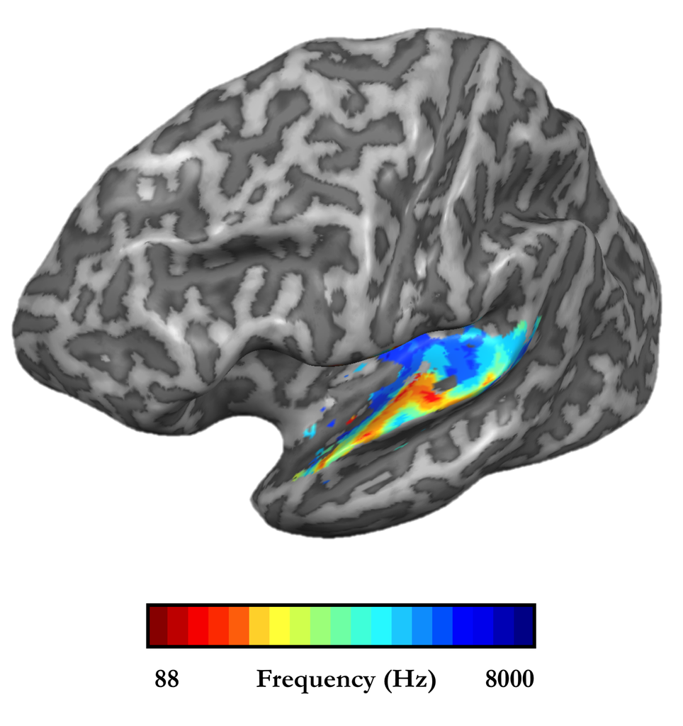

## Research Question

- Does frequency representation in human primary auditory cortex change due to environmental circumstances?
- Does long-term sensory deprivation of one modality (i.e., vision) affect the cortical sensory representation of another modality (i.e., audition)

## Dataset Composition

- 2 Subject Groups:
  - 13 **Early Blind** (EB; 8 congenital, 5 anophthalmic)
  - 17 **Sighted Controls** (SC)
- 2 Sites:
  - University of Oxford (7T)
  - University of Washington (3T)
- 2 Stimulus Types:
  - Moving auditory sweeps
  - Static pure tone bursts

## The Brain as a Linear System

Terminology:

1. Input, \(X_{n}\)
2. Operator, \(H()\)
3. Output, \(Y_{n}\)

\[ Y = H(X) \]

\[ Y_{1} + Y_{2} = H(X_{1}) + H(X_{2}) \]

Shiny applications not supported in static R Markdown documents

## Population Receptive Field (pRF) Modeling

- Frequency selectivity or tuning as a 1D Gaussian in log frequency space
- 1D Gaussian has 3 parameters: center (\(\mu\)), spread (\(\sigma\)), and amplitude (\(a\))

Shiny applications not supported in static R Markdown documents

## Measures Obtained from the pRF Model

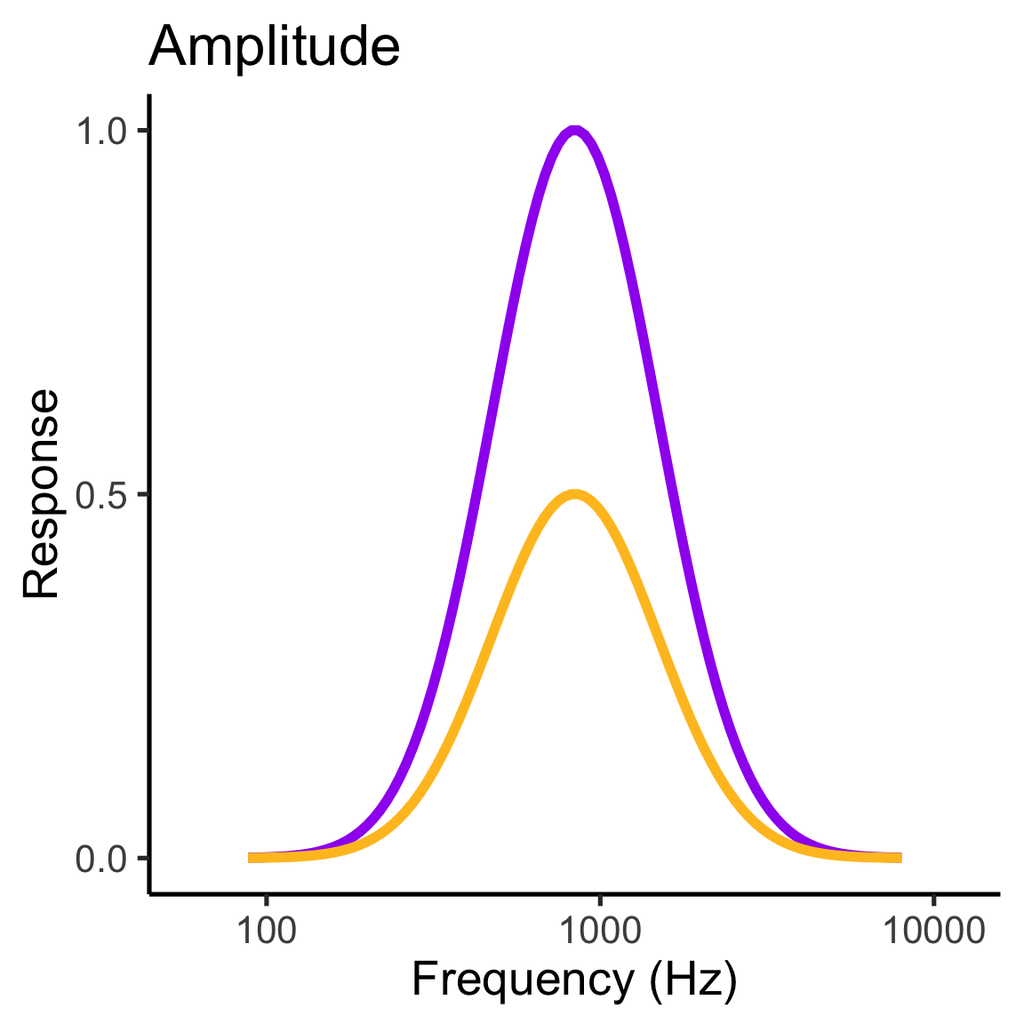

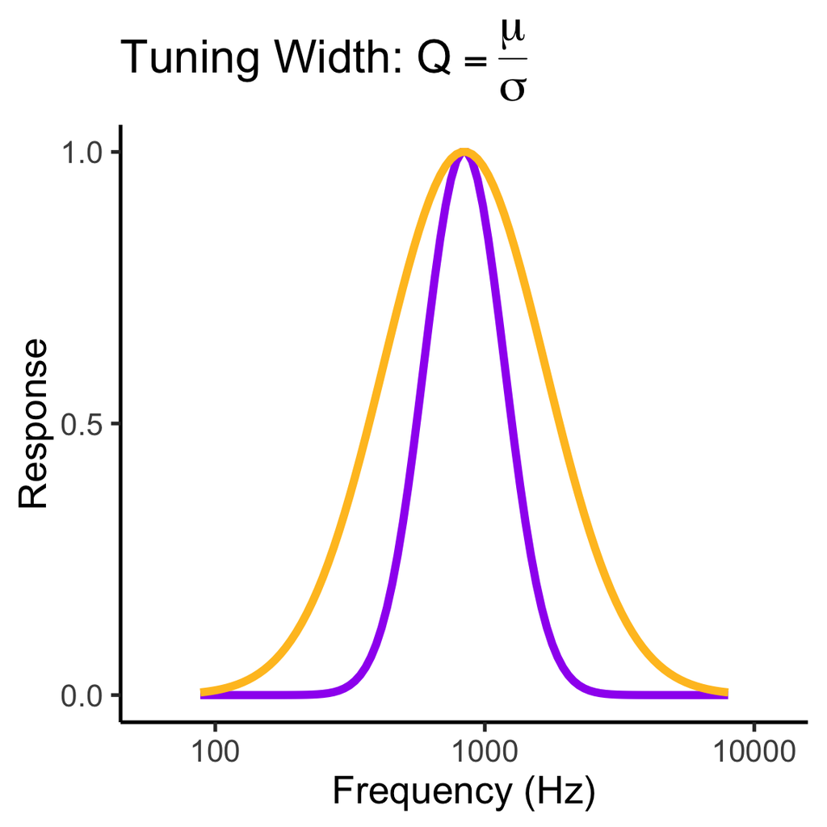

## Amplitude Response within PAC

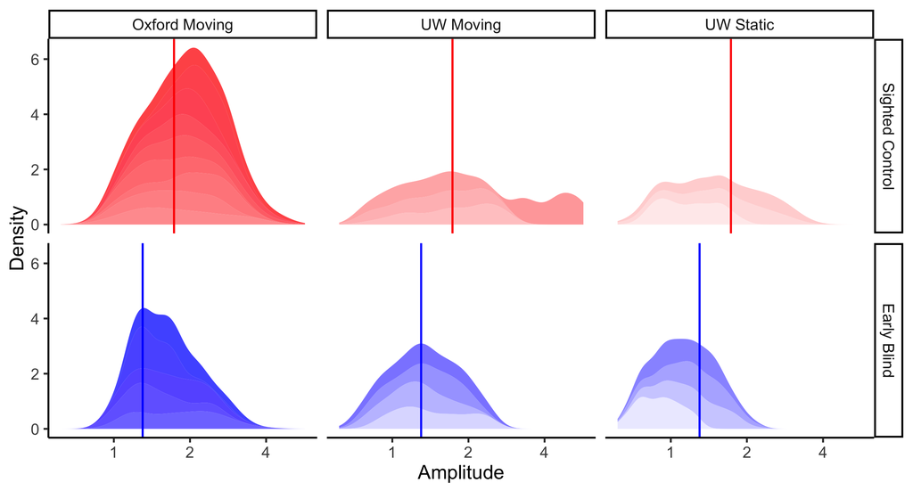

## Tuning Widths with PAC

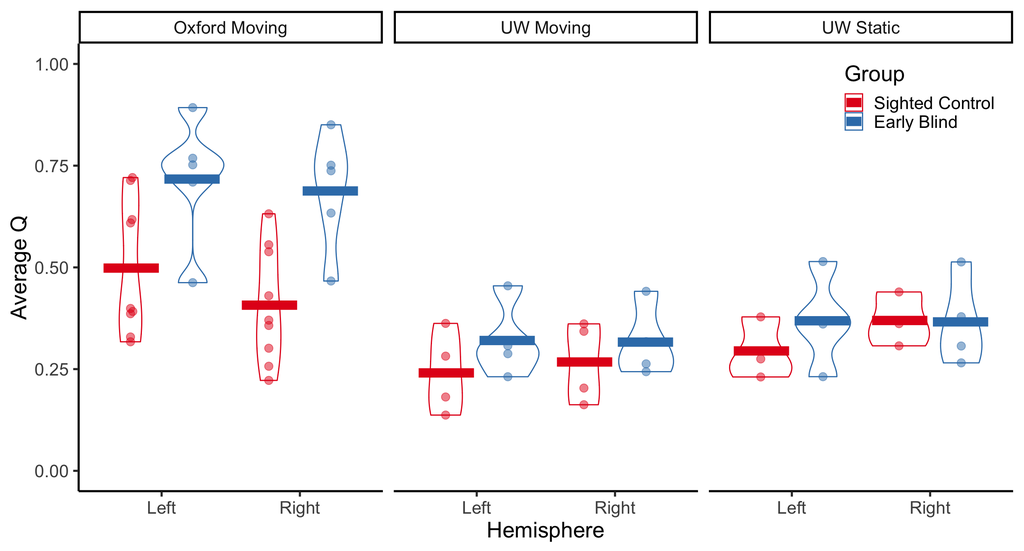

## Conclusions

- Decreased response amplitudes in Early Blind vs. Sighted Control subjects
- Potentially due to increased "*efficiency*" of processing within PAC or recruitment of reorganized occipital cortex (Jiang et al., 2014)
- Early Blind subjects had significantly narrower voxel-wise tuning for auditory frequencies within PAC vs. Sighted Control subjects
- Evidence supporting cortical plasticity in a primary sensory cortices due to sensory depreviation or increased task demand

Shiny applications not supported in static R Markdown documents

**Questions?**